# Visuals for Time-Dependent Variables

Muhammad Hilmi Abdul Majid

## Introduction

Now, let’s explore visuals that can be used for time-dependent variables. In this case, typically, there would be two (or more) variables or columns in the data. The first variable or column is the variable of interest that changes depending on time, and the second variable or column is the details regarding the time at which the first variable has that value.

As usual, we first load the `ggplot2` and `dplyr` packages.

```r
library(ggplot2)
library(dplyr)
```

## Text to Date

We have mentioned this before in the earlier topic but it still important that it should be included in this topic specific for time-dependent variables. Typically, the time variable or column is recorded in text format. For example, if you open a CSV or an Excel file, it may be recorded as “21-February-2001” or “21/02/2001”. When loading datasets with time column, R will read it as string or text and will not treat it as date or time. Thus, it is important to first change the column or variable type so that R understands that the variable refers to time.

Let’s look at one example where the dates are stored as text or string. The `class()` function can be used to check an object’s class.

```r
value <- rnorm(10)
time <- c("1/1/2025","2/1/2025","3/1/2025","4/1/2025","5/1/2025",
          "6/1/2025","7/1/2025","8/1/2025","9/1/2025","10/1/2025")
data <- data.frame(value, time)

# Check the class object of time
class(data$time)
```

```
## [1] "character"
```

As we can see, the `time` column has the `character` (or text/string) class format. We can change the format to time by using the `dmy()` function from the `lubridate` package.

```r
# install.packages("lubridate") # In case you have not downloaded it yet
library(lubridate)

# Convert the time column to time format
data <- mutate(data, time=dmy(time))

# Check the class object of time
class(data$time)
```

```
## [1] "Date"
```

The `lubridate` package contains several functions to transform value stored in character or numeric to date. These functions include: `dmy()`, `myd()`, `ymd()`, `ydm()`, `dym()`, `mdy()`, and `ymd_hms()`. Choosing which function to use depends on the data that we have. If the original data is written in the form of day-month-year, then we use `dmy()`. If on the other hand the data is written in form of month-day-year, we use `mdy()` instead. The good thing about `lubridate` is that the functions are flexible in the treatment of heterogeneous formats. That is, it does not matter if the data is written as “1-Jan-2001” or “1/1/2001” or “01-01-2001” and so on.

```r
dmy("2-March-2010")
```

```
## [1] "2010-03-02"
```

```r
mdy("Feb/3/2010")
```

```
## [1] "2010-02-03"
```

Note that if the data only contains year, without month and day, you can treat the year variable as a numbers and may not need to convert it to time/date format.

## Line Charts

For our first example here, we will use the `economics` dataset from the `ggplot2` package. It is a data that shows various economic time series for the United States. Suppose we want to look at personal savings rate in the US. We can display the changes in the values using `geom_point()` to draw a scatterplot.

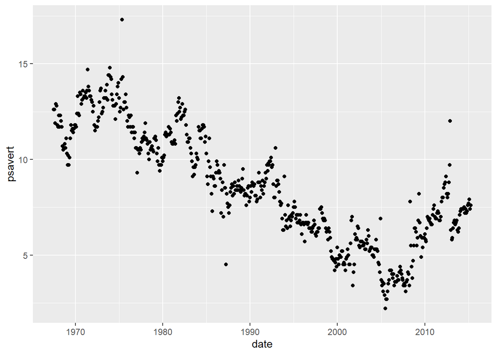

```r
# Specify the data and mapping
ggplot(data=economics, mapping=aes(x=date, y=psavert)) +

  # Draw scatterplot
  geom_point()
```

However, scatterplot is not the best for time series. Using line chart where we have lines connecting the consequtive points is better as it emphasizes the order of data. We can draw a line chart using `geom_line()`.

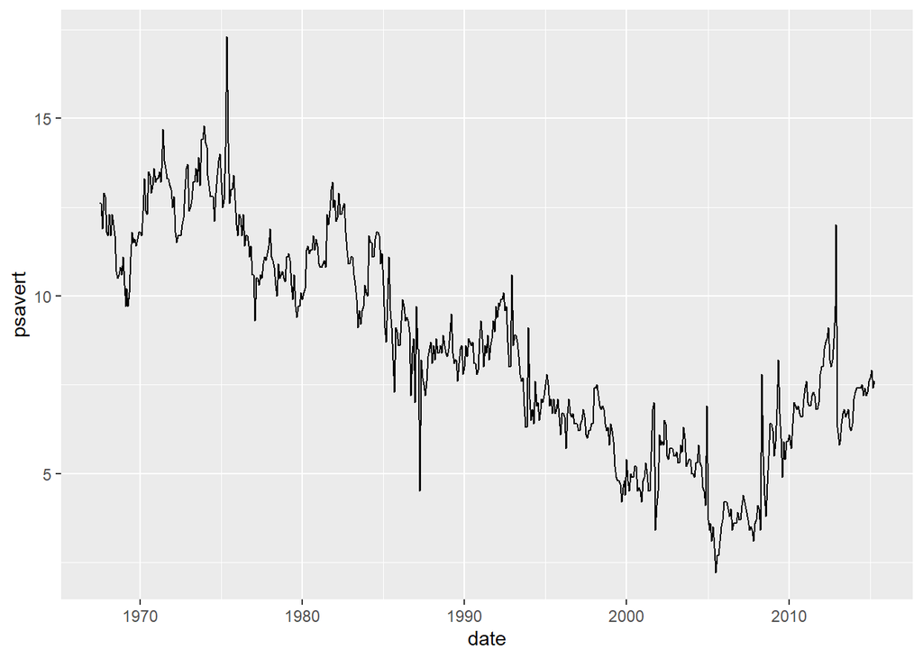

```r
# Specify the data and mapping
ggplot(data=economics, mapping=aes(x=date, y=psavert)) +

  # Draw line chart
  geom_line()
```

We can see that the personal savings rate fluctuates a lot, but in general the value decreases from 1970s to around 2005, and then the value increases a bit until 2015. We can add a smoothed line that represent the trend using `geom_smooth()`.

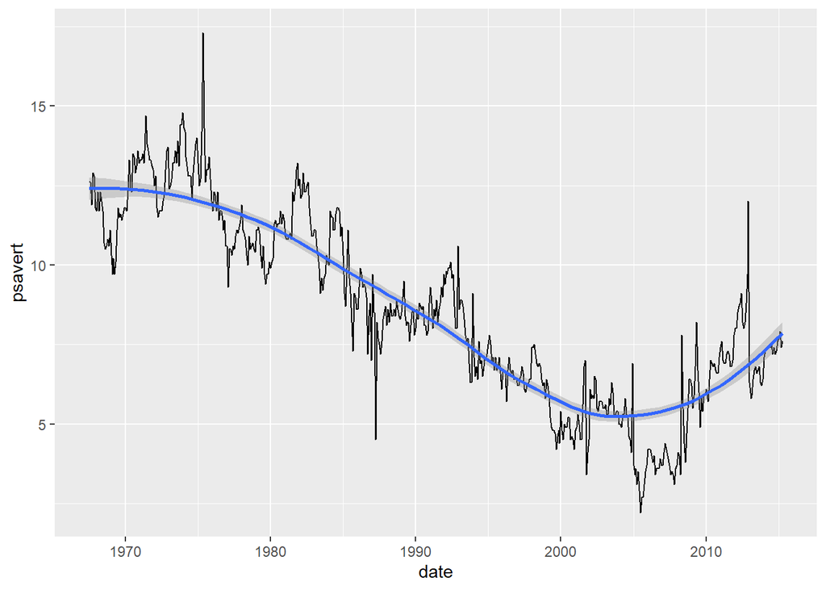

```r
# Specify the data and mapping
ggplot(data=economics, mapping=aes(x=date, y=psavert)) +

  # Draw line chart
  geom_line() +

  # Draw nonparametric smoothed line
  geom_smooth()
```

Further modification of the lines include:

- `alpha`: Transparency of the line.
- `color`: Color of the line .
- `linetype`: Type of the line (0 = blank, 1 = solid, 2 = dashed, 3 = dotted, 4 = dotdash, 5 = longdash, 6 = twodash). It can either be specified in the given integer or by the name.
- `linewidth`: Width of the line.

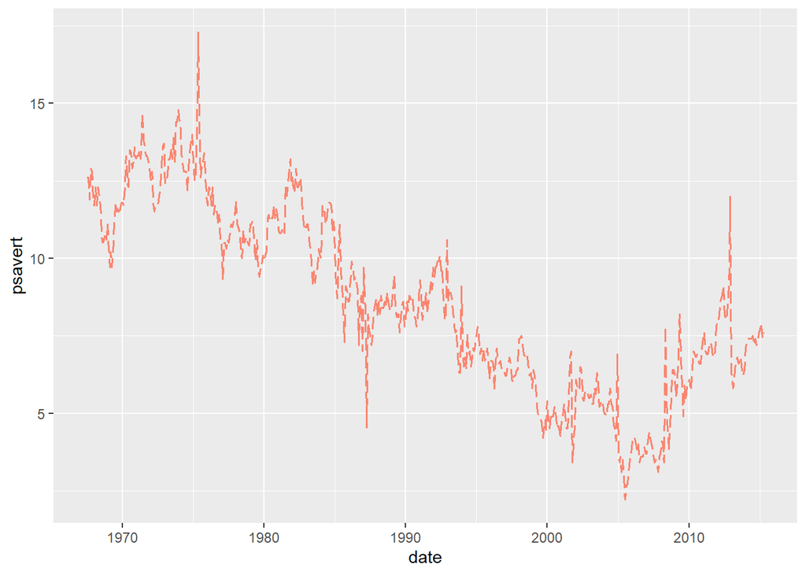

```r
# Specify the data and mapping
ggplot(data=economics, mapping=aes(x=date, y=psavert)) +

  # Draw line chart
  # Use tomato as the color, make it 25% transparent or 75% opaque,
  # Use longdash line type, and 0.6 line width.
  geom_line(color="tomato",
            alpha=0.75,
            linetype="longdash",
            linewidth=0.6)
```

When drawing a line chart for time series, we can modify the scale of the x-axis using `scale_x_date()` or `scale_x_datetime()`. You can check how to write down the format by looking at the `strptime()` help page by running `help(strptime)` or `?strptime` in the console.

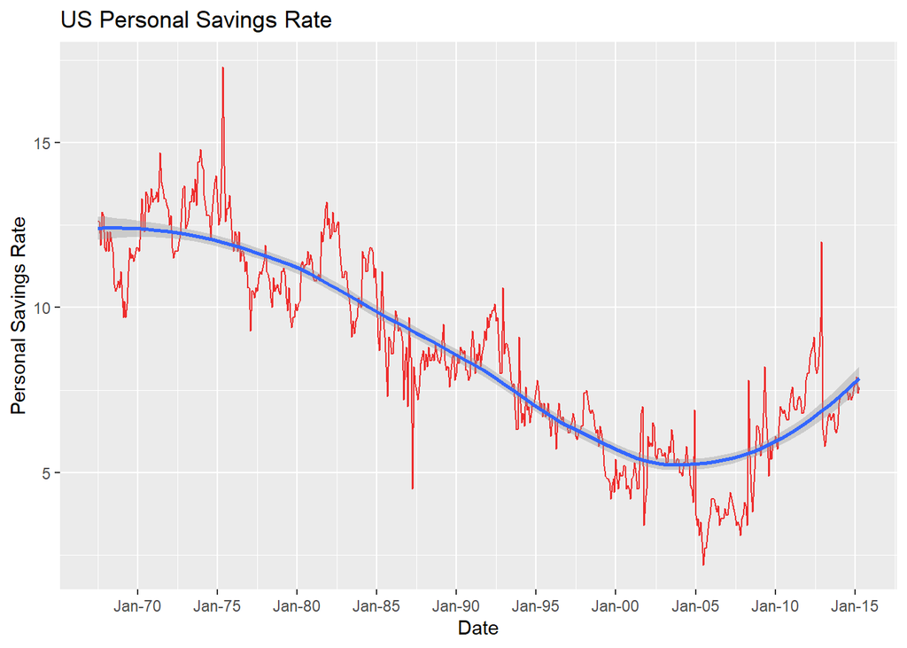

```r
# Specify the data and mapping
ggplot(data=economics, mapping=aes(x=date, y=psavert)) +

  # Draw line chart
  geom_line(color = "firebrick2") +

  # Draw smoothed line
  geom_smooth() +

  # Change the scale for x-axis to every 5 years,
  # change labels to the given format
  scale_x_date(date_breaks = "5 years",
               labels = scales::date_format("%b-%y")) +

  # Add title, change x and y-axes labels
  labs(title="US Personal Savings Rate",
       x="Date", y="Personal Savings Rate")
```

## Multiple Line Charts

In many cases, we may have two or more time series that we want to draw both of them on the same plot. Line charts are especially useful for this case as lines that represent categories or different time series can be made easily distinguishable from one another.

Here, we will use the `gapminder` dataset from the `dslabs` package. It is similar to the previously used `gapminder` dataset from `gapminder` package, but with more variables.

First, let’s see what happens if we simply filter the data from Malaysia and Singapore, and use the same mapping as before.

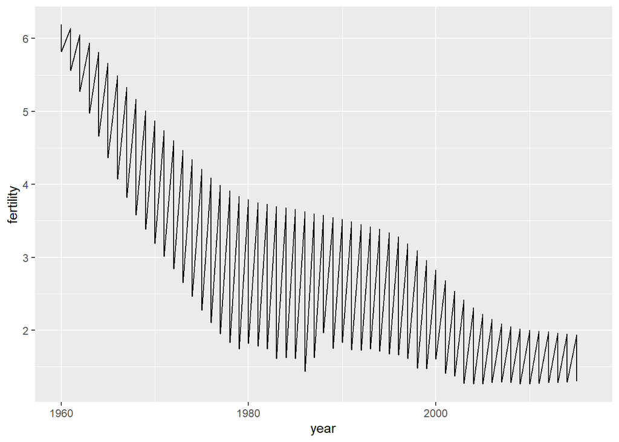

```r
# install.packages("dslabs")
library(dslabs)

# Filter data for Malaysia and Singapore only
regional_data <- filter(gapminder, country %in% c("Malaysia","Singapore"))

# Specify the data and mapping
ggplot(data=regional_data, mapping=aes(x=year, y=fertility)) +

  # Draw line chart
  geom_line()
```

Clearly, this is not what we want. What happened here is that we do not specify that we want to treat the two countries differently. Thus, a single line is used to draw for both Malaysia and Singapore.

There are two ways to tell R and `geom_line()` that we want to draw them separately. First is specifying `group` argument or option in `aes()` mapping. Doing this draws two unlabelled lines.

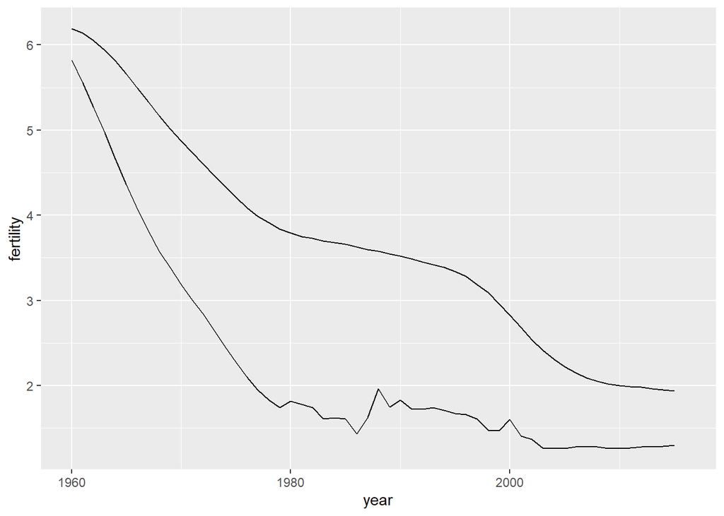

```r
# Specify the data and mapping, group the data by country
ggplot(data=regional_data, mapping=aes(x=year, y=fertility, group=country)) +

  # Draw line chart
  geom_line()
```

Another way to do this is to use the `color` argument in the `aes()` mapping. This is similar to what we have used in previous topics.

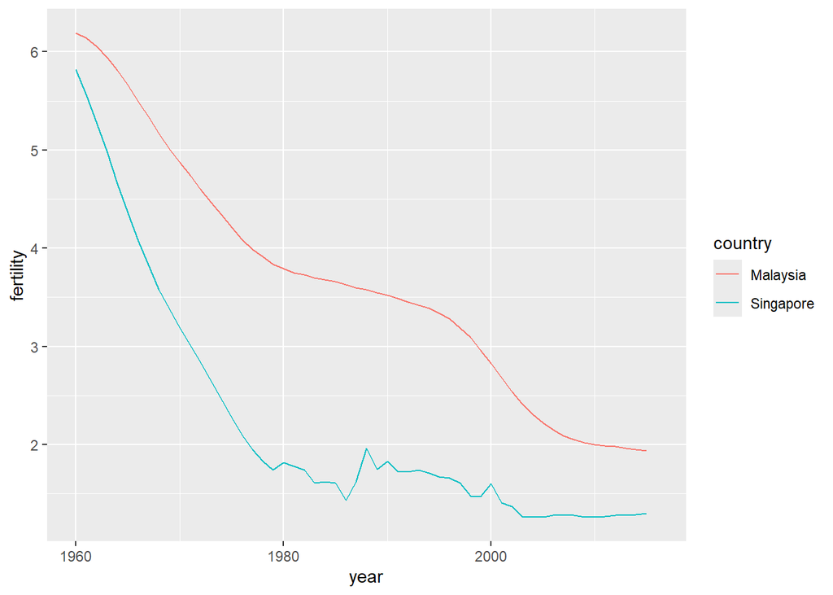

```r
# Specify the data and mapping, color the line by country
ggplot(data=regional_data, mapping=aes(x=year, y=fertility, color=country)) +

  # Draw line chart
  geom_line()
```

We can see that from 1960 to 2015, Malaysia consistently has higher fertility rate than Singapore. However, both seems to trend downward with Singapore plateauing around 1.3 children per woman.

We can even add more lines in the chart if we want to. However, adding too much lines cause the chart hard to be read and understood.

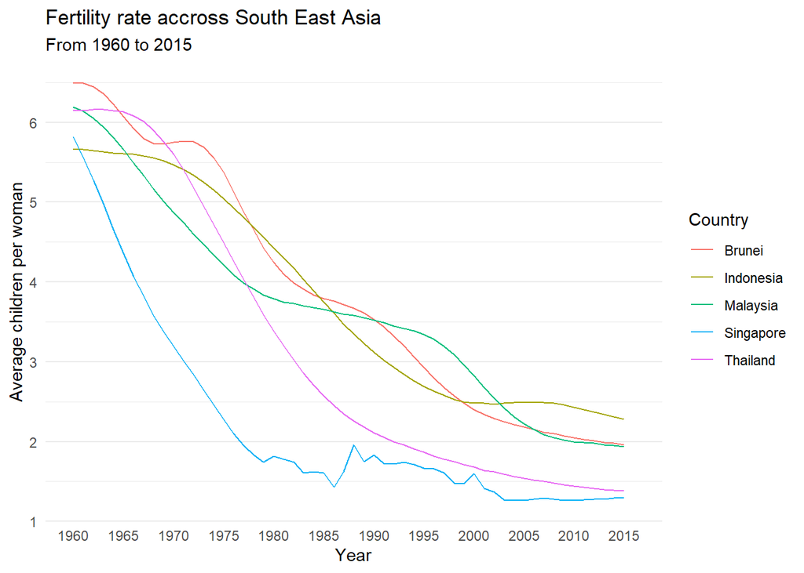

```r
# Filter data to the given countries
regional_data <- filter(gapminder,
                        country %in% c("Brunei","Malaysia",
                                       "Singapore","Thailand","Indonesia"))

# Specify the data and mapping
ggplot(data=regional_data, mapping=aes(x=year, y=fertility, color=country)) +

  # Draw line chart
  geom_line() +

  # Change the scale for y-axis to 1,2,3,...,7
  scale_y_continuous(breaks=1:7) +

  # Change the scale for x-axis to 1960 to 2015 by 5 years
  scale_x_continuous(breaks=seq(1960,2015,by=5)) +

  # Add title, subtitle, change x and y-axes labels
  labs(x="Year", y="Average children per woman",
       color="Country",
       title="Fertility rate accross South East Asia",
       subtitle="From 1960 to 2015") +

  # Remove background color
  theme_minimal() +

  # Remove grids on x-axis
  theme(panel.grid.major.x = element_blank(),
        panel.grid.minor.x = element_blank())
```

## Area Charts

Area chart is another form of line chart, except that the area under the line is filled. To draw it, use the `geom_area()` function.

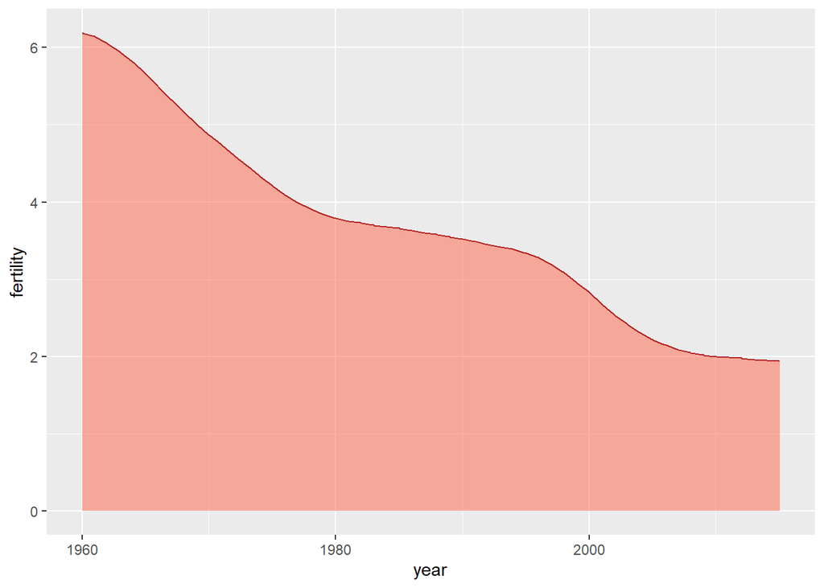

```r
# Filter data to Malaysia only
MY_data <- filter(gapminder, country=="Malaysia")

# Specify the data and mapping
ggplot(data=MY_data, mapping=aes(x=year, y=fertility)) +

  # Draw area chart
  geom_area(fill="tomato",
            color="firebrick",
            alpha=0.5)
```

The stacked area chart on the other hand stacked the total values of the y-axis at a given x-axis value. This occurs when `fill` or `color` are used for grouping. Note that this graph is only useful when the total makes sense. For example, we can use it to see population in South East Asia by country, as the total population can be obtained by adding each country’s population. But using it for fertility rate does not make sense because fertility rate should not be added across countries.

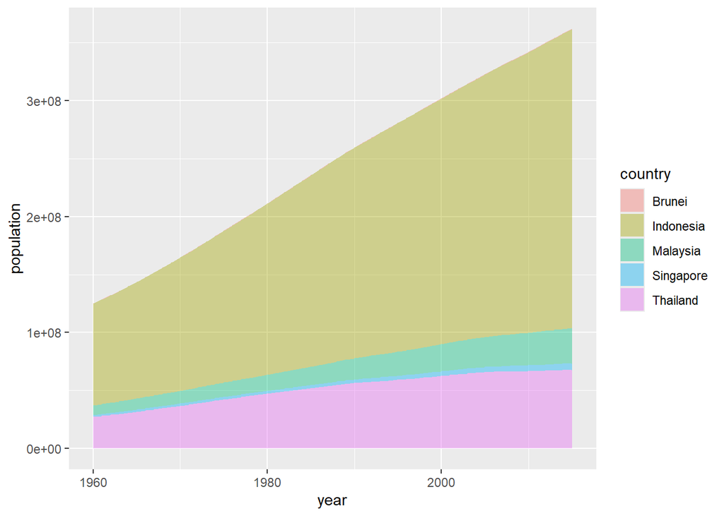

```r
# Filter data for given countries only
regional_data <- filter(gapminder,
                        country %in% c("Brunei","Malaysia",
                                       "Singapore","Thailand","Indonesia"))

# Specify the data and mapping, fill colors by country
ggplot(data=regional_data, mapping=aes(x=year, y=population, fill=country)) +

  # Draw area chart, use 60% transparency or 40% opacity
  geom_area(alpha=0.4)
```

If we want the area chart with grouping not to stacked but overlap, we can use `geom_ribbon()`. To use the function, we have to specify the lower y value with `ymin` and the upper y value with `ymax`. The area between `ymin` and `ymax` will be filled.

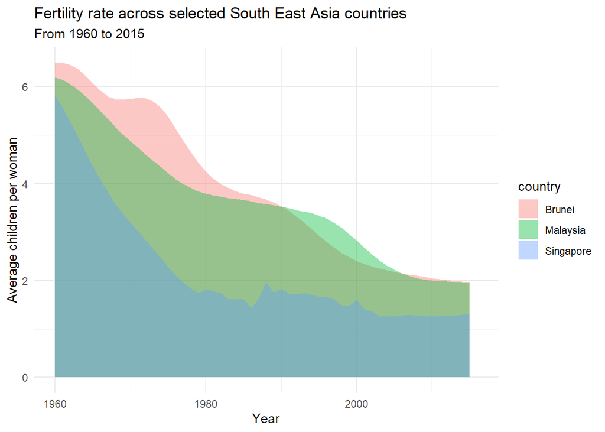

```r
# Filter data for given countries only
regional_data <- filter(gapminder,
                        country %in% c("Brunei","Malaysia",
                                       "Singapore"))

# Specify the data and mapping
ggplot(data=regional_data, mapping=aes(x=year, y=fertility, fill=country)) +

  # Draw area chart where area starts from y=0 to y=fertility
  geom_ribbon(alpha=0.4, mapping=aes(ymin=0, ymax=fertility)) +

  # Add title, subtitle, change x and y-axes labels, legend
  labs(x="Year", y="Average children per woman",
       color="Country",
       title="Fertility rate across selected South East Asia countries",
       subtitle="From 1960 to 2015") +

  # Use minimal theme
  theme_minimal()
```

## Slope Graphs

Slope graphs is another useful visualization used to display data with time-dependent variables. It is used when we have a few categories or groups with a few time points. You can think of slope chart as a minimization of the line chart where the x-axis refers to time, y-axis refers to the value of interest, and there would be lines connecting between points. However, the slope graph removes visual clutter like the x and y-axes, the grid lines, and many more.

To draw a slope graph, we can use the `newggslopegraph()` function from `CGPfunctions` package. The requires the dataset from where variables are from, the time variable, the value or measurement variable, and the grouping variable. Additionally, the time variable must be a factor, not numeric. We can convert an object or variable to factor by using `as.factor()` function.

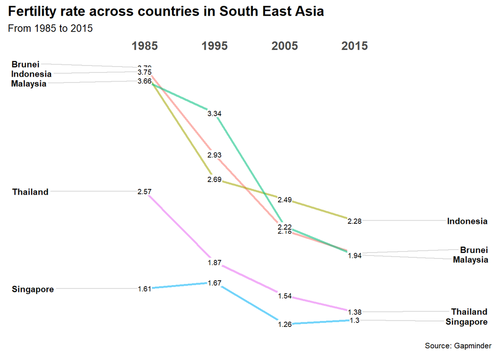

```r
# install.packages("CGPfunctions")
library(CGPfunctions)

# Filter data for given countries and year only
regional_data <- filter(gapminder,
                        country %in% c("Brunei","Malaysia",
                                       "Singapore","Thailand","Indonesia") &
                          year %in% c(1985,1995,2005,2015))

# Change the year column from numeric to factor
regional_data <- mutate(regional_data, year=as.factor(year))

# Draw slope graph
newggslopegraph(dataframe=regional_data, Times=year,
                Measurement=fertility, Grouping=country) +

  # Add title, subtitle, caption
  labs(title="Fertility rate across countries in South East Asia",
       subtitle="From 1985 to 2015",
       caption="Source: Gapminder")
```

The slope graph is not particularly useful if we have more than five time points or more than five groups or categories. If too many time points or groups are used, the visual becomes cluttered. At that point, using a line chart might be better.

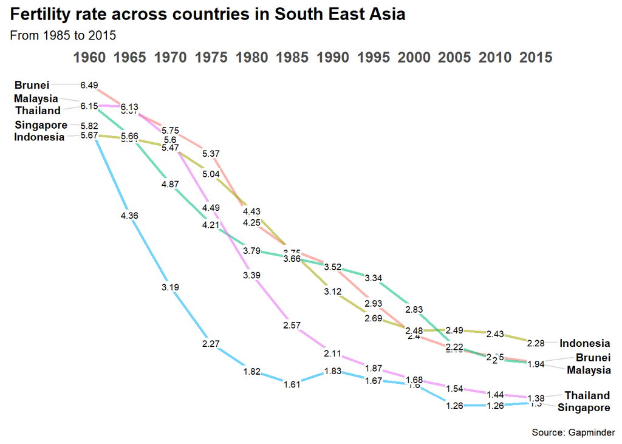

```r
regional_data <- filter(gapminder,
                        country %in% c("Brunei","Malaysia",
                                       "Singapore","Thailand","Indonesia") &
                          year %in% seq(1960,2015,by=5))

regional_data <- mutate(regional_data, year=as.factor(year))

newggslopegraph(dataframe=regional_data, Times=year,
                Measurement=fertility, Grouping=country) +
  labs(title="Fertility rate across countries in South East Asia",
       subtitle="From 1985 to 2015",
       caption="Source: Gapminder")
```

## Dumbbell Charts

Dumbbell chart is another useful tool to display data with time element. This chart is used to compare two values, either before and after, max and min, or in the case of time-dependent variable, two different points of time.

We can draw dumbbell chart by using `geom_point()` to draw points on the chart that represent the two different time point values, and `geom_segment()` to draw the lines connecting the two points. But before doing that, we may need modify the data so that the values in the two time points are in different columns. We can do this using `pivot_wider()` in `tidyr` package.

```r
library(tidyr)

# Modify data
regional_data <- gapminder %>%

  # Filter data for selected region and year only
  filter(region=="South-Eastern Asia" & year %in% c(1990,2010)) %>%

  # Select these columns only
  select(country,year,life_expectancy)%>%

  # Transform to wide format using year as the column names
  # and life expectancy as the value in the column
  pivot_wider(names_from = "year",
              values_from ="life_expectancy")

# Change the column names
names(regional_data) <- c("country","y1990","y2010")

# Show modified data
regional_data
```

```
## # A tibble: 10 × 3
##    country     y1990 y2010
##    <fct>       <dbl> <dbl>
##  1 Brunei       73.8  77.1
##  2 Cambodia     57.6  67
##  3 Indonesia    64    69.8
##  4 Lao          51.5  64.1
##  5 Malaysia     71.8  74.4
##  6 Philippines  67.6  70.1
##  7 Singapore    74.9  81.3
##  8 Thailand     71    74.2
##  9 Timor-Leste  58.5  70.8
## 10 Vietnam      69.3  74.5
```

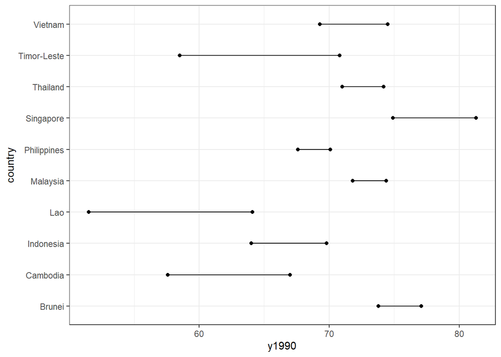

```r
# Specify the data and mapping
ggplot(data=regional_data, mapping=aes(y=country)) +

  # Draw segmented lines from x=1990 values to x=2010 values
  geom_segment(mapping=aes(x=y1990, xend=y2010)) +

  # Draw points at x=1990 values
  geom_point(mapping=aes(x=y1990)) +

  # Draw points at x=2010 values
  geom_point(mapping=aes(x=y2010))
```

We can further improve the chart by giving the two points different colors, and changing other visual properties. We can also order the y-axis according to one of the values.

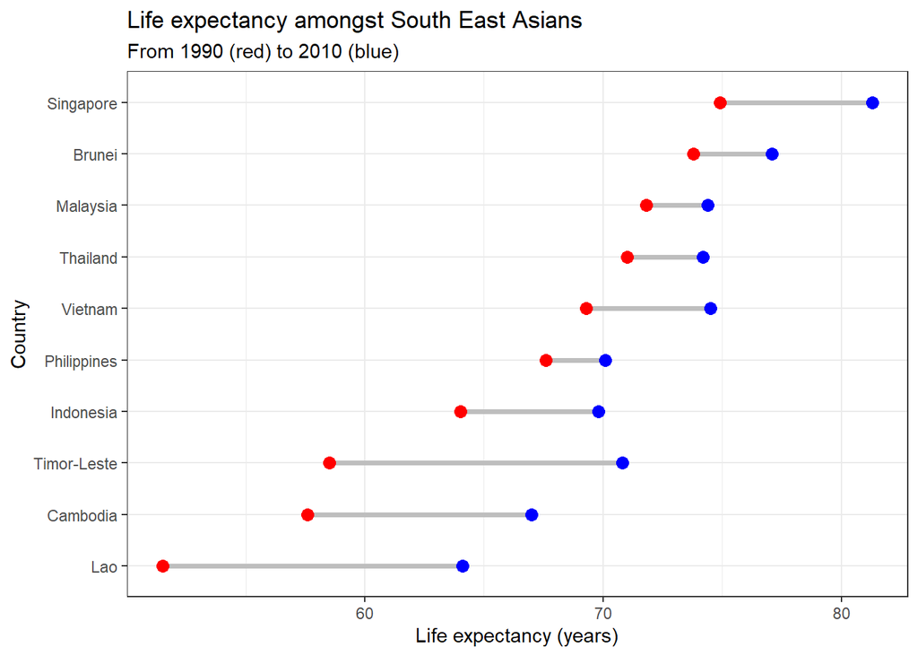

```r
# Specify the data and mapping, reorder countries by the 1990 life expectancies
ggplot(data=regional_data, mapping=aes(y=reorder(country,y1990))) +

  # Draw segmented lines
  geom_segment(mapping=aes(x=y1990, xend=y2010),
               color="grey",
               linewidth=1.25) +

  # Draw points for 1990
  geom_point(mapping=aes(x=y1990), color="red", size=3) +

  # Draw points for 2010
  geom_point(mapping=aes(x=y2010), color="blue", size=3) +

  # Add title, subtitle, change x and y-axes labels
  labs(x="Life expectancy (years)", y="Country",
       title="Life expectancy amongst South East Asians",
       subtitle="From 1990 (red) to 2010 (blue)")
```

In the dumbbell chart above, we can see that Lao had the lowest life expectancy in 1990, followed by Cambodia and Timor-Leste. But these countries had a massive improvement in their life expectancy in 2010. Additionally, Singapore seems to consistently has higher life expectancy compared to the rest in South East Asia.

Alternatively, we can use the `geom_dumbell()` function included in the `ggalt` package to draw the dumbbell chart.

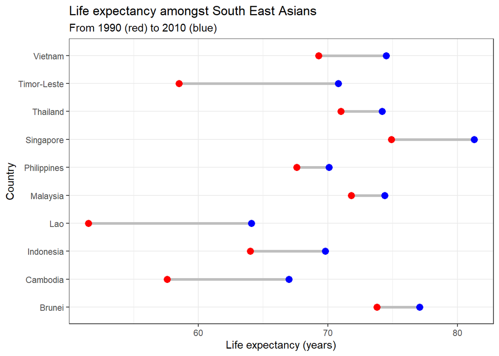

```r
# install.packages("ggalt")
library(ggalt)

ggplot(data=regional_data, mapping=aes(y=country, x=y1990, xend=y2010)) +
  geom_dumbbell(size = 1.25,
                size_x = 3,
                size_xend = 3,
                colour = "grey",
                colour_x = "red",
                colour_xend = "blue") +
  labs(x="Life expectancy (years)", y="Country",
       title="Life expectancy amongst South East Asians",
       subtitle="From 1990 (red) to 2010 (blue)")
```

## Connected Scatterplots

Our last visual that we want to discuss in this topic is the connected scatterplot. The regular scatterplot draws points in the x-y position corresponding to the x-y variables. In connected scatterplots, we have two time dependent-variables, which will become the x-y variables, and we draw the points for different time points.

To draw the connected scatterplots, we can use `geom_point()` to draw the points, and `geom_segment()` to draw the lines connecting the time points.

In the example below, we first filter the data to only for March, June, September, and December. This is to reduce the clutter in the connected scatterplot. Then, we draw points in the x-y coordinate according to unemployment and personal savings rate. Next, we draw segmented lines where the lines start with values at a time point and end with values at the next time point. This is performed by setting `x=unemploy` and `y=psavert` (vectors values for a time point) and `xend=c(unemploy[-1], NA)` and `yend=c(psavert[-1],NA)` (vector values for the next time point with the same length as before).

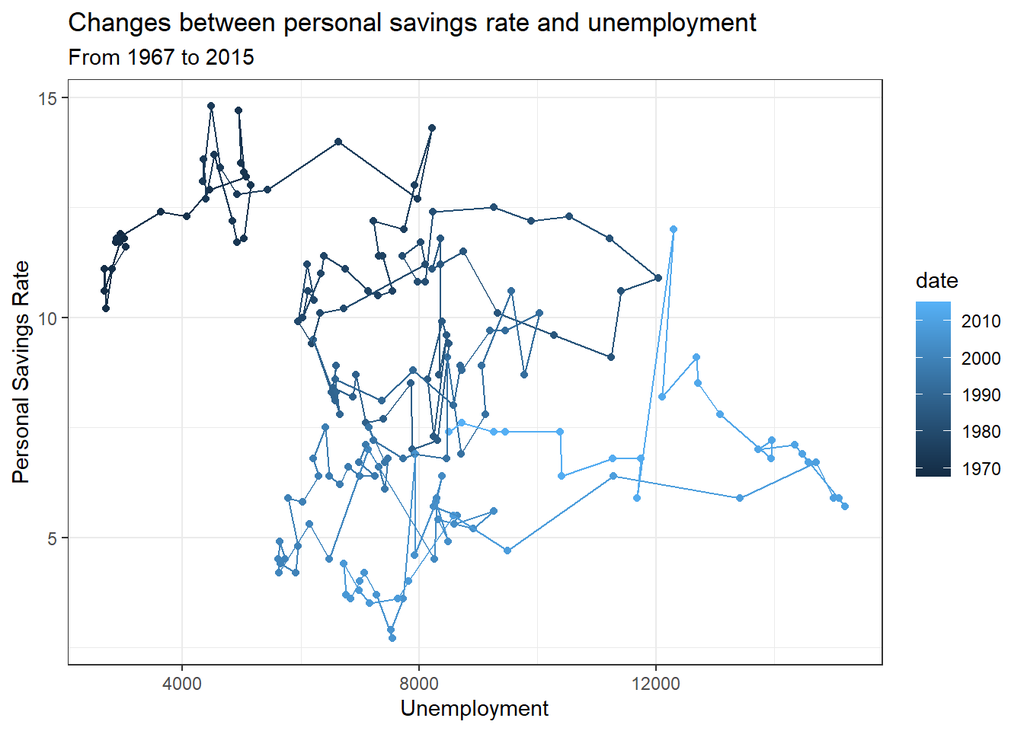

```r
# Filter data to the selected months only
economics2 <- filter(economics, month(date) %in% c(3,6,9,12))

# Specify the data and mapping
ggplot(data=economics2, mapping=aes(x=unemploy, y=psavert, color=date)) +

  # Draw points according to the x and y values
  geom_point() +

  # Draw segmented lines to connect the points
  geom_segment(aes(xend=c(unemploy[-1], NA),
                   yend=c(psavert[-1], NA))) +

  # Add title and subtitle, change x and y-axes labels
  labs(x="Unemployment", y="Personal Savings Rate",
       title="Changes between personal savings rate and unemployment",
       subtitle="From 1967 to 2015")
```

## Conclusion

In this topic, we have explored some visuals and graphic options we can use when we want to display data with time-dependent variables. In most cases, we will use some form of line charts, but there are other options that can be used depending on the type of visual summary we want to show.